# ai-04-practice1-ans

### AI-04 Practice 1

#### Sample notebook for multiple linear regression (MLR)

線形重回帰分析の手順例

#### Import libraries

```python
import sys
import numpy as np
import pandas as pd
from pandas.plotting import scatter_matrix
import seaborn as sns
import matplotlib
import matplotlib.pyplot as plt
from pandas.plotting import register_matplotlib_converters
register_matplotlib_converters()
from sklearn import preprocessing
import statsmodels.api as sm
import statsmodels.formula.api as smf
```

#### Import my libraries

```python
my_libs_dir = '../'
if not my_libs_dir in sys.path:
    sys.path.append(my_libs_dir)  # add the path to my_lib directory

# The following lines are needed to auto-reload my library file
# Without these lines, my library file is read only once and
# modifications of my library file are not reflected.
%load_ext autoreload
%autoreload 1
%aimport my_libs.linear_reg
# import from my library file
from my_libs.linear_reg import step_aic_forward, calc_vifs
```

#### Parameters

```python
%config InlineBackend.figure_formats = {'png', 'retina'}  # for high-reso graph
plt.rcParams['font.family'] = 'Yu Mincho' # for Japanese in graph (Win10)

# To show all rows and columns in the results
pd.options.display.max_rows = 999
pd.options.display.max_columns = 999
```

#### Step 1. Collect possible explanatory variables

目的変数に影響を与えていそうな要因は、可能な限り網羅的に説明変数に取り入れる。

##### Check & read CSV file, replace column labels if needed, etc.

encoding='shift-jis' may be needed.  
CSVファイルをチェックしてから読み込む。必要に応じて列ラベルを変更。  
CSVファイルの漢字コードがShift-JISの場合は encoding='shift-jis' が必要。

```python
csv_in = 'infection1.csv'
#df_all = pd.read_csv(csv_in, delimiter=',', skiprows=0, header=None)
df_all = pd.read_csv(csv_in, delimiter=',', skiprows=0, header=0)
# no header in csv, so set columns explicitly
#df_all.columns = ['sex', 'len', 'd', 'h', 'w_all', 'w_meat', 'w_gut', 'w_shell', 'ring']
print(df_all.shape)
print(df_all.info())
display(df_all.head())
```

```
(100, 6)
<class 'pandas.core.frame.DataFrame'>
RangeIndex: 100 entries, 0 to 99
Data columns (total 6 columns):
 #   Column    Non-Null Count  Dtype
---  ------    --------------  -----
 0   marker1   100 non-null    float64
 1   marker2   100 non-null    float64
 2   marker3   100 non-null    float64
 3   marker4   100 non-null    float64
 4   marker5   100 non-null    float64
 5   severity  100 non-null    int64
dtypes: float64(5), int64(1)
memory usage: 4.8 KB
None
```

|  | marker1 | marker2 | marker3 | marker4 | marker5 | severity |
| --- | --- | --- | --- | --- | --- | --- |
| 0 | 6.8 | 4.9 | 3.3 | -5.5 | 7.8 | 1 |
| 1 | 4.6 | 3.1 | 2.8 | 10.3 | 5.2 | 6 |
| 2 | 5.9 | 7.4 | 3.2 | 0.4 | 9.9 | 4 |
| 3 | 3.5 | 2.9 | 8.5 | 2.6 | 9.9 | 4 |
| 4 | 4.0 | 2.6 | 4.9 | 1.4 | 6.5 | 4 |

**Ans1. 100**

##### Check numerical / category variables if needed

数値列・カテゴリー列の様子をみる

```python
display(df_all.describe())
#display(df_all.describe(exclude='number'))
```

|  | marker1 | marker2 | marker3 | marker4 | marker5 | severity |
| --- | --- | --- | --- | --- | --- | --- |
| count | 100.000000 | 100.000000 | 100.000000 | 100.000000 | 100.000000 | 100.000000 |
| mean | 5.014000 | 4.008000 | 3.272000 | 2.147000 | 7.151000 | 4.390000 |
| std | 0.955687 | 2.053412 | 3.064132 | 4.066305 | 3.538461 | 1.963788 |
| min | 2.300000 | -0.900000 | -5.600000 | -7.400000 | -1.500000 | 0.000000 |
| 25% | 4.400000 | 2.675000 | 1.550000 | -0.600000 | 5.175000 | 3.000000 |
| 50% | 5.000000 | 4.050000 | 3.100000 | 2.050000 | 6.750000 | 4.000000 |
| 75% | 5.600000 | 5.600000 | 5.500000 | 4.950000 | 9.825000 | 6.000000 |
| max | 7.500000 | 8.400000 | 9.300000 | 11.300000 | 15.800000 | 9.000000 |

##### See rows including missing data

欠損値を含む行を表示してみる

```python
#display(df_all[df_all.isnull().any(axis=1)])
```

##### Delete rows including missing data, or fill missing data

欠損値を含む行を削除する (または欠損値を埋める)

```python
#df_all = df_all.dropna().reset_index(drop=True)
##df_all = df_all.fillna(df_all.mean()) # if you want to fill missing data instead of deleting them
#print(df_all.shape)
#display(df_all.head())
```

##### Separate explanatory variables and objective variable

説明変数と目的変数を分ける

```python
X_all_org = df_all.loc[:, 'marker1':'marker5']  # explanatory variables
y = df_all['severity']  # objective variable
print('X_all_org:', X_all_org.shape)
display(X_all_org.head())
print('y:', y.shape)
print(y.head())
```

```
X_all_org: (100, 5)
```

|  | marker1 | marker2 | marker3 | marker4 | marker5 |
| --- | --- | --- | --- | --- | --- |
| 0 | 6.8 | 4.9 | 3.3 | -5.5 | 7.8 |
| 1 | 4.6 | 3.1 | 2.8 | 10.3 | 5.2 |
| 2 | 5.9 | 7.4 | 3.2 | 0.4 | 9.9 |
| 3 | 3.5 | 2.9 | 8.5 | 2.6 | 9.9 |
| 4 | 4.0 | 2.6 | 4.9 | 1.4 | 6.5 |

```
y: (100,)
0    1
1    6
2    4
3    4
4    4
Name: severity, dtype: int64
```

##### Apply get_dummies()

ダミー変数化

```python
#X_all = pd.get_dummies(X_all_org, drop_first=True)
X_all = X_all_org.copy()
#print('X_all:', X_all.shape)
#display(X_all.head())
```

#### Step 2. Scatter plot and correlation coefficients between all combination of explanatory variables

変数間の総当たり散布図を描画。相関係数も算出しておく

##### all by all Pearson correlation coefficients;

総当たりのPearson相関係数

```python
corr_all = X_all.corr(method='pearson')
display(corr_all)
```

|  | marker1 | marker2 | marker3 | marker4 | marker5 |
| --- | --- | --- | --- | --- | --- |
| marker1 | 1.000000 | 0.143138 | 0.048427 | -0.033753 | 0.136502 |
| marker2 | 0.143138 | 1.000000 | -0.119983 | 0.015705 | 0.468006 |
| marker3 | 0.048427 | -0.119983 | 1.000000 | -0.046751 | 0.763901 |
| marker4 | -0.033753 | 0.015705 | -0.046751 | 1.000000 | -0.071796 |
| marker5 | 0.136502 | 0.468006 | 0.763901 | -0.071796 | 1.000000 |

##### Pickup explanatory variable pairs with large absolute value of correlation coefficient;

相関係数の絶対値が大きい説明変数ペアの出力

Method 1. Straight forward method

```python
th_corr = 0.3
n_X = corr_all.shape[0]
corr_large = []
for i in range(n_X):
    for j in range(i+1, n_X):
        cc1 = corr_all.iat[i,j]
        if cc1 < -th_corr or cc1 > th_corr:
            corr_large.append([corr_all.columns[i], corr_all.columns[j], cc1])
corr_large.sort(reverse=True, key=lambda x: abs(x[2]))
display(corr_large)
```

```
[['marker3', 'marker5', 0.7639009878271125],
 ['marker2', 'marker5', 0.46800649233656805]]
```

Method 2. Rather tricky method ...

```python
th_corr = 0.3
keep = np.triu(np.ones(corr_all.shape), k=1).astype('bool').flatten()
#print(np.ones(corr_all.shape))  # debug
#print(np.triu(np.ones(corr_all.shape), k=1))  # debug
#print(np.triu(np.ones(corr_all.shape), k=1).astype('bool'))  # debug
#print(keep)  # debug
triu = corr_all.stack()[keep]
#print(corr_all.stack())  # debug
triu_sorted = triu[ np.abs(triu).sort_values(ascending=False).index ]
#print(np.abs(triu).sort_values(ascending=False))  # debug
#print(np.abs(triu).sort_values(ascending=False).index)  # debug
print(triu_sorted[ (triu_sorted < -th_corr) | (triu_sorted > th_corr) ])
```

```
marker3  marker5    0.763901
marker2  marker5    0.468006
dtype: float64
```

##### all by all scatter plots of explanatory variables;

変数間の総当たり散布図

```python
#scatter_matrix(X_all, figsize=(30,30))
#plt.show()
```

##### if you want to use seaborn instead of matplotlib

seabornを使うなら

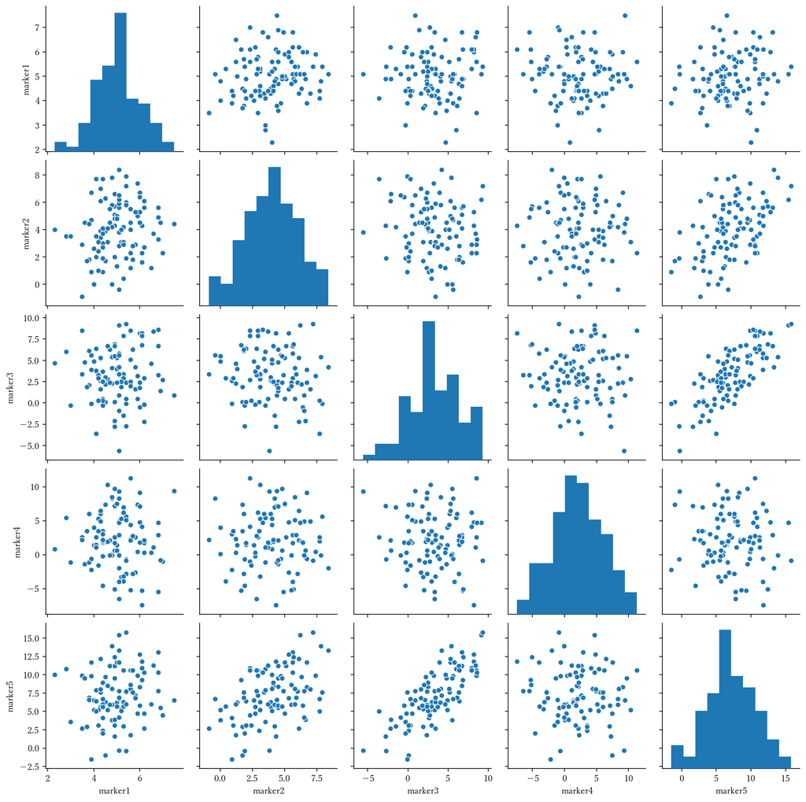

```python
sns.pairplot(X_all)
plt.show()
```

##### Heatmap

Heatmapを描いてもよい

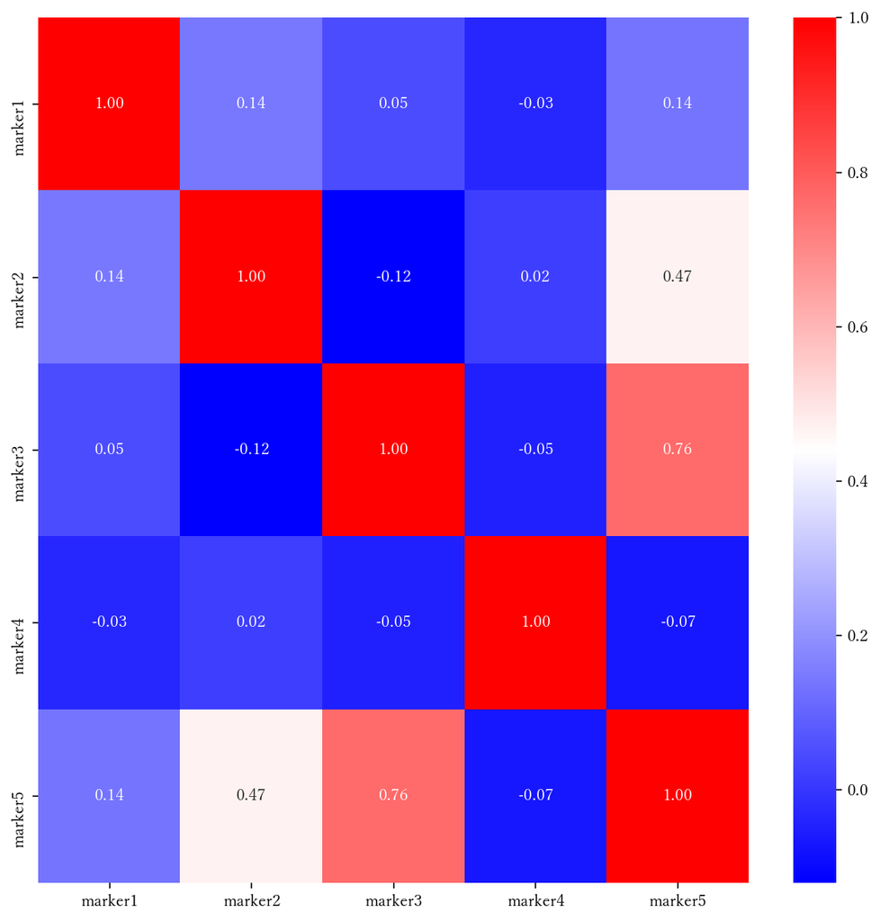

```python
plt.figure(figsize=(10,10))
sns.heatmap(corr_all,annot=True,fmt='.2f',cmap='bwr')
plt.show()
```

#### Step 3. MLR calculation using all variables

全説明変数を用いて、標準化なしで線形重回帰分析

```python
X_all_c = sm.add_constant(X_all)
model = sm.OLS(y, X_all_c)
results = model.fit()
print(results.summary())
```

```
                            OLS Regression Results
==============================================================================
Dep. Variable:               severity   R-squared:                       0.820
Model:                            OLS   Adj. R-squared:                  0.810
Method:                 Least Squares   F-statistic:                     85.65
Date:                Tue, 28 Apr 2020   Prob (F-statistic):           1.87e-33
Time:                        22:12:35   Log-Likelihood:                -123.13
No. Observations:                 100   AIC:                             258.3
Df Residuals:                      94   BIC:                             273.9
Df Model:                           5
Covariance Type:            nonrobust
==============================================================================
                 coef    std err          t      P>|t|      [0.025      0.975]
------------------------------------------------------------------------------
const          5.2816      0.482     10.956      0.000       4.324       6.239
marker1       -0.2851      0.091     -3.126      0.002      -0.466      -0.104
marker2        0.4340      0.087      4.971      0.000       0.261       0.607
marker3       -0.2709      0.080     -3.388      0.001      -0.430      -0.112
marker4        0.2367      0.021     11.083      0.000       0.194       0.279
marker5       -0.1151      0.078     -1.474      0.144      -0.270       0.040
==============================================================================
Omnibus:                        4.678   Durbin-Watson:                   1.833
Prob(Omnibus):                  0.096   Jarque-Bera (JB):                2.370
Skew:                          -0.033   Prob(JB):                        0.306
Kurtosis:                       2.249   Cond. No.                         63.3
==============================================================================

Warnings:
[1] Standard Errors assume that the covariance matrix of the errors is correctly specified.
```

```python
#help(results)
#print(dir(results))  # To know all methods/attributes of an object
```

#### Step 4. Check R2 and Adjusted R2 to see whether MLR is appropriate for this data

決定係数や自由度調整済み決定係数をみて、そもそも線形モデルの当てはめが妥当かどうかを判断

```python
print('R2:', results.rsquared)
print('Adj R2:', results.rsquared_adj)
```

```
R2: 0.8200175124310455
Adj R2: 0.8104439758582288
```

Rather good ...

**Ans2. 0.82**

#### Step 5. Stat. test for MLR equation

重回帰式の検定 (求めた重回帰式は目的変数を説明している？)

```python
print('p-values (F-statistic)', results.f_pvalue)
```

```
p-values (F-statistic) 1.866925062556276e-33
```

Very small p-value, so this MLR equation is considered to be significant.

#### Step 6. Standardization of variables

Compare coefficients for explanatory variables  
全説明変数と目的変数を標準化して線形重回帰分析  
標準化偏回帰係数を比較

```python
# NOTE: after scaling, X_scaled and Y_scaled are ndarray, not DataFrame.
X_scaled = preprocessing.scale(X_all)
y_scaled = preprocessing.scale(y)
model = sm.OLS(y_scaled, X_scaled)
results = model.fit()
print(results.summary())
```

```
                                 OLS Regression Results
=======================================================================================
Dep. Variable:                      y   R-squared (uncentered):                   0.820
Model:                            OLS   Adj. R-squared (uncentered):              0.811
Method:                 Least Squares   F-statistic:                              86.57
Date:                Tue, 28 Apr 2020   Prob (F-statistic):                    8.04e-34
Time:                        22:12:35   Log-Likelihood:                         -56.149
No. Observations:                 100   AIC:                                      122.3
Df Residuals:                      95   BIC:                                      135.3
Df Model:                           5
Covariance Type:            nonrobust
==============================================================================
                 coef    std err          t      P>|t|      [0.025      0.975]
------------------------------------------------------------------------------
x1            -0.1387      0.044     -3.143      0.002      -0.226      -0.051
x2             0.4538      0.091      4.997      0.000       0.273       0.634
x3            -0.4227      0.124     -3.406      0.001      -0.669      -0.176
x4             0.4901      0.044     11.142      0.000       0.403       0.577
x5            -0.2074      0.140     -1.482      0.142      -0.485       0.070
==============================================================================
Omnibus:                        4.678   Durbin-Watson:                   1.833
Prob(Omnibus):                  0.096   Jarque-Bera (JB):                2.370
Skew:                          -0.033   Prob(JB):                        0.306
Kurtosis:                       2.249   Cond. No.                         6.35
==============================================================================

Warnings:
[1] Standard Errors assume that the covariance matrix of the errors is correctly specified.
```

#### Step 7. Feature selection

変数選択

```python
# NOTE: make DataFrames corresponding to X_scaled and y_scaled.
dfX_scaled = pd.DataFrame(X_scaled, columns=X_all.columns)
dfy_scaled = pd.Series(y_scaled, name=y.name)
exog = list(dfX_scaled.columns)  # Initial set = all explanatory variables
endog = [dfy_scaled.name]  # Objective variables
df_scaled = pd.concat([dfX_scaled, dfy_scaled], axis=1)
```

##### by forward selection method based on AIC

変数増加法による変数選択

```python
results_aic=step_aic_forward(smf.ols, exog, endog, data=df_scaled)
```

```
AIC: 285.788, formula: severity ~ 1
AIC: 272.883, formula: severity ~ marker5
AIC: 229.344, formula: severity ~ marker3
AIC: 285.834, formula: severity ~ marker1
AIC: 270.801, formula: severity ~ marker2
AIC: 253.837, formula: severity ~ marker4
AIC: 223.031, formula: severity ~ marker3 + marker5
AIC: 229.268, formula: severity ~ marker3 + marker1
AIC: 211.365, formula: severity ~ marker3 + marker2
AIC: 169.852, formula: severity ~ marker3 + marker4
AIC: 150.727, formula: severity ~ marker3 + marker4 + marker5
AIC: 169.060, formula: severity ~ marker3 + marker4 + marker1
AIC: 132.666, formula: severity ~ marker3 + marker4 + marker2
AIC: 132.188, formula: severity ~ marker3 + marker4 + marker2 + marker5
AIC: 124.584, formula: severity ~ marker3 + marker4 + marker2 + marker1
AIC: 124.298, formula: severity ~ marker3 + marker4 + marker2 + marker1 + marker5
The best formula: severity ~ marker3 + marker4 + marker2 + marker1 + marker5
Minimum AIC: 124.298
```

```python
print(results_aic.aic)
print(results_aic.model.exog_names)
print(results_aic.model.endog_names)
```

```
124.29813423007286
['Intercept', 'marker3', 'marker4', 'marker2', 'marker1', 'marker5']
severity
```

#### Step 8. Check of multicolinearity (VIF checkup)

マルチコのチェック

- Iteration of Variable selection (selected_cols) <-> Check VIF  
  until all VIFs < 10.
- NOTE: standardization of variables does not affect the results

Format of results of statsmodels: https://www.statsmodels.org/dev/generated/statsmodels.regression.linear_model.RegressionResults.html

```python
endogs = results_aic.model.endog_names
exogs = results_aic.model.exog_names.copy()
exogs.remove('Intercept')
print(exogs)  # debug
X_c = sm.add_constant(X_all[exogs])
vifs = calc_vifs(X_c, y)
display(vifs)
```

```
['marker3', 'marker4', 'marker2', 'marker1', 'marker5']
```

|  | VIF |
| --- | --- |
| const | 31.790822 |
| marker3 | 8.130393 |
| marker4 | 1.021183 |
| marker2 | 4.352391 |
| marker1 | 1.028638 |
| marker5 | 10.339324 |

How to eliminate multicolinearity is case by case.  
Here we simply delete an explanatory variable with high VIF.

```python
exogs.remove('marker5')
print(exogs)  # debug
X_c = sm.add_constant(X_all[exogs])
vifs = calc_vifs(X_c, y)
display(vifs)
```

```
['marker3', 'marker4', 'marker2', 'marker1']
```

|  | VIF |
| --- | --- |
| const | 31.786353 |
| marker3 | 1.021028 |
| marker4 | 1.003419 |
| marker2 | 1.038264 |
| marker1 | 1.026639 |

For all explantory variables, VIF < 10, so we can go forward.

#### Step 9. Estimate the magnitude of the influence of each explanatory variable on the objective variable

最終的に得られた標準化偏回帰係数から、各説明変数の目的変数に対する影響の大きさがわかる

```python
X_final_scaled = dfX_scaled[exogs]
model_final_scaled = sm.OLS(y_scaled, X_final_scaled)
results_final_scaled = model_final_scaled.fit()
print(results_final_scaled.summary())
```

```
                                 OLS Regression Results
=======================================================================================
Dep. Variable:                      y   R-squared (uncentered):                   0.816
Model:                            OLS   Adj. R-squared (uncentered):              0.808
Method:                 Least Squares   F-statistic:                              106.3
Date:                Tue, 28 Apr 2020   Prob (F-statistic):                    2.14e-34
Time:                        22:12:35   Log-Likelihood:                         -57.292
No. Observations:                 100   AIC:                                      122.6
Df Residuals:                      96   BIC:                                      133.0
Df Model:                           4
Covariance Type:            nonrobust
==============================================================================
                 coef    std err          t      P>|t|      [0.025      0.975]
------------------------------------------------------------------------------
marker3       -0.5947      0.044    -13.439      0.000      -0.683      -0.507
marker4        0.4987      0.044     11.367      0.000       0.412       0.586
marker2        0.3363      0.045      7.536      0.000       0.248       0.425
marker1       -0.1416      0.044     -3.191      0.002      -0.230      -0.054
==============================================================================
Omnibus:                        1.206   Durbin-Watson:                   1.806
Prob(Omnibus):                  0.547   Jarque-Bera (JB):                1.066
Skew:                          -0.034   Prob(JB):                        0.587
Kurtosis:                       2.499   Cond. No.                         1.22
==============================================================================

Warnings:
[1] Standard Errors assume that the covariance matrix of the errors is correctly specified.
```

```python
print(results_final_scaled.params)
```

```
marker3   -0.594741
marker4    0.498679
marker2    0.336326
marker1   -0.141614
dtype: float64
```

The order of strengths of influences on objective variables:  
**Ans3.**  
**marker3 (negative) > marker4 (positive) > marker2 (positive) > marker1 (negative)**  
（これが、目的変数severityに対する各説明変数(markerX)の影響の大きさ順）

#### Step 10. Stat. test for MLR equation

重回帰式の検定 (求めた重回帰式は目的変数を説明している？)

```python
print('p-values (F-statistic)', results_final_scaled.f_pvalue)
```

```
p-values (F-statistic) 2.144426648181679e-34
```

Very small p-value, so this MLR equation is considered to be significant.

#### Step 11. MLR calculation using selected explanatory variables

選択された説明変数を用いて、標準化なしで線形重回帰分析

```python
X_final_c = sm.add_constant(X_all[exogs])
model_final = sm.OLS(y, X_final_c)
results_final = model_final.fit()
print(results_final.summary())
```

```
                            OLS Regression Results
==============================================================================
Dep. Variable:               severity   R-squared:                       0.816
Model:                            OLS   Adj. R-squared:                  0.808
Method:                 Least Squares   F-statistic:                     105.2
Date:                Tue, 28 Apr 2020   Prob (F-statistic):           4.95e-34
Time:                        22:12:36   Log-Likelihood:                -124.28
No. Observations:                 100   AIC:                             258.6
Df Residuals:                      95   BIC:                             271.6
Df Model:                           4
Covariance Type:            nonrobust
==============================================================================
                 coef    std err          t      P>|t|      [0.025      0.975]
------------------------------------------------------------------------------
const          5.2900      0.485     10.907      0.000       4.327       6.253
marker3       -0.3812      0.029    -13.369      0.000      -0.438      -0.325
marker4        0.2408      0.021     11.307      0.000       0.199       0.283
marker2        0.3216      0.043      7.497      0.000       0.236       0.407
marker1       -0.2910      0.092     -3.175      0.002      -0.473      -0.109
==============================================================================
Omnibus:                        1.206   Durbin-Watson:                   1.806
Prob(Omnibus):                  0.547   Jarque-Bera (JB):                1.066
Skew:                          -0.034   Prob(JB):                        0.587
Kurtosis:                       2.499   Cond. No.                         45.1
==============================================================================

Warnings:
[1] Standard Errors assume that the covariance matrix of the errors is correctly specified.
```

#### Step 12. Check R2 and Adjusted R2

決定係数や自由度調整済み決定係数をみて、線形モデルの当てはまりの良さをチェック

```python
print('R2:', results_final.rsquared)
print('Adj R2:', results_final.rsquared_adj)
```

```
R2: 0.815856512614229
Adj R2: 0.8081031026190386
```

**Ans4. 0.81**

#### Step 13. partial regression coefficients

最終的に得られた偏回帰係数から、「各説明変数が1増えたときの目的変数の増分」がわかる。

```python
print(results_final.params)
```

```
const      5.290001
marker3   -0.381167
marker4    0.240833
marker2    0.321647
marker1   -0.290995
dtype: float64
```

Coefficients of MLR;  
Increment of objective variable when corresponding variable is increased by 1  
and other variables are not changed

#### Obtained best model:

**Ans5. severity $\sim$ 5.29 + (-0.38) *marker3 + 0.24* marker4 + (0.32) *marker2 + (-0.29)* marker1**

**Ans6. 0.32**